# Gov 50 Final Project

Sara Kumar

12-12-2023

# Introduction

What is the relationship between political affiliation and the percentage of POC female elected officials in the House of Representatives? In this study, I plan to examine race trends in female elected representatives in the House of Representatives to see if there is a directly proportional relationship between political party and the number of POC female representatives. I hypothesize that there will be statistically significant correlation between elected female Democratic representatives and the amount of POC female representation. For example, as seen historically, California, a left-leaning state, has elected more African Americans to Congress than any other state. Furthermore, Congress has been getting progressively more diverse in recent years.

Understanding this project and research question is significant because if the data determines there is a strong correlation between the political party and the percentage of white elected representatives, we as a voter population can understand the priorities and values of Democrats versus Republicans which can then inform our voting decisions in upcoming elections/ offer voters the space to decide if this information is enough to change our opinions on which political party we choose to support.

# Data Section

This is a cross-sectional study since I am analyzing the current female officials in the House of Representatives. The explanatory variable of interest/ the independent variable of this study is the political party of each female representative. The outcome variable is race of each elected official/ the percentage of white elected officials. These variables are measured from the Center for American Women and Politics’ data set on elected House of Representative officials.

```r
library(tidyverse)
library(gov50data)
library(dplyr)
```

```r
stateofficials <- read.csv("officeholders_positions.csv")

stateofficials <- stateofficials |>
  mutate(white = ifelse(grepl("White", race_ethnicity), 1, 0))
```

### Racial Distribution of Democratic Party Female Representatives (1/2 of Dependent Variable)

The following visual displays a bar plot of the racial distribution of all elected female Democratic representatives and counts the number of elected officials of each respective race.

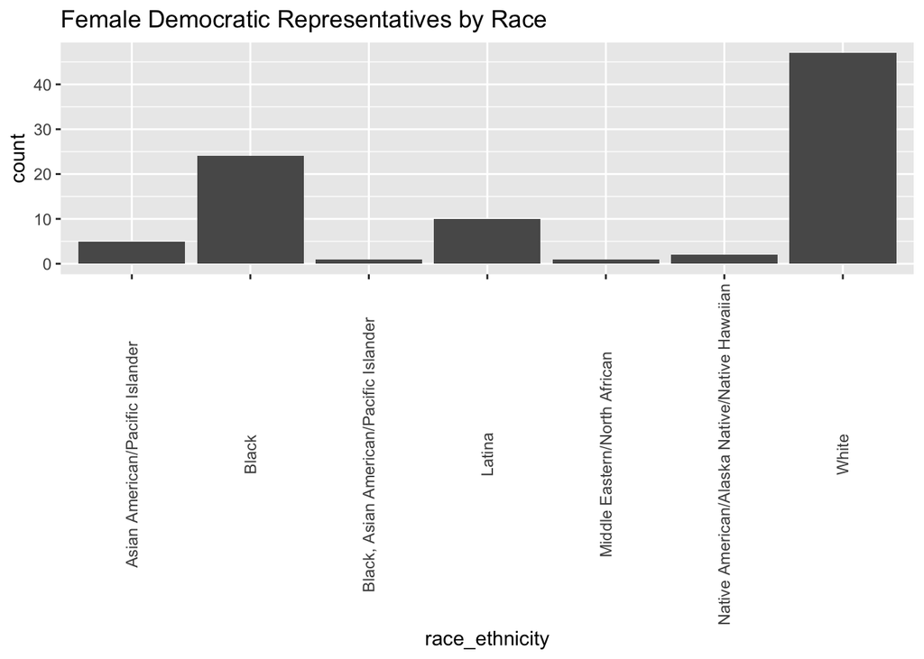

```r
dems <- stateofficials %>%
  filter(party == 'Democrat')
ggplot(data=dems, aes(x=race_ethnicity)) +
geom_bar() +
  theme(axis.text.x = element_text(angle = 90, vjust = 0.5)) +
  labs(title = "Female Democratic Representatives by Race")
```

### Racial Distribution of Republican Party Female Representatives (2/2 of Dependent Variable)

The following figure displays a bar plot of the racial distribution of all elected female Republican representatives and counts the number of elected officials of each respective race.

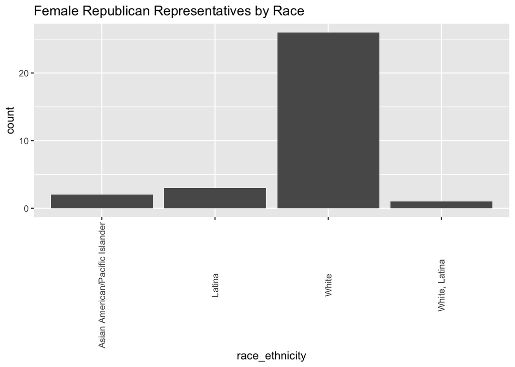

```r
reps <- stateofficials %>%
  filter(party == 'Republican')
ggplot(data=reps, aes(x=race_ethnicity)) +
geom_bar() +
  theme(axis.text.x = element_text(angle = 90, vjust = 0.5)) +
  labs(title = "Female Republican Representatives by Race")
```

One important limitation of this data is the fact that there are more female Democratic elected officials in the House of Representatives. This means there is more data to map/ analyze which likely leads to greater racial representation, making the Democratic outcome variable seem more favorable in POC representation. However, since I will offering a descriptive analysis of each distinct political party and comparing those results, this difference should not impact the credibility of my results.

As I proceed into the next observations and analyses, if my difference-in-means and regression model demonstrates that there is a strong correlation between greater numbers of POC female elected officials in the Democratic party relative to the Republican party, this would provide support for my hypothesis. If, on the other hand, the models do not demonstrate a statistically strong relationship between increased POC female representation the Democratic party versus the Republican, this would provide evidence against my hypothesis.

# Results

### Comparing Racial Distribution Between Parties (Combined Comparison of Dependent Variable)

The following visual displays a grouped bar plot that counts the POC versus non POC representation for each party of all elected female representatives.

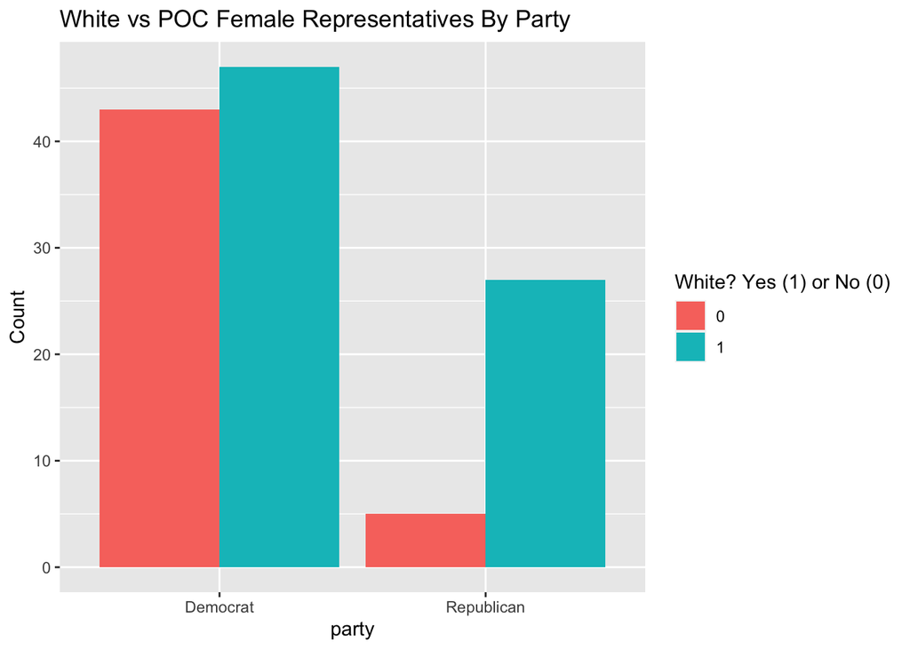

```r
library(ggplot2)

binary_plot <- stateofficials |>
  group_by(party, white) |>
  summarize(Count = n()) |>
  ggplot(aes(x = party, y= Count, fill = as.factor(white))) +
    geom_bar(position="dodge", stat = "identity")
binary_plot <- binary_plot +
  guides(fill=guide_legend(title="White? Yes (1) or No (0)")) +
  ggtitle("White vs POC Female Representatives By Party")

binary_plot
```

### Determining if There is a Relationship Between Political Party and Percentage of White Representatives

##### Difference in means:

```r
set.seed(02138)
library(infer)

ate <- stateofficials |>
  specify(white ~ party) |>
  calculate(stat = "diff in means", order = c("Democrat", "Republican"))

ate
```

```
## Response: white (numeric)
## Explanatory: party (factor)
## # A tibble: 1 × 1
##     stat
##    <dbl>
## 1 -0.322
```

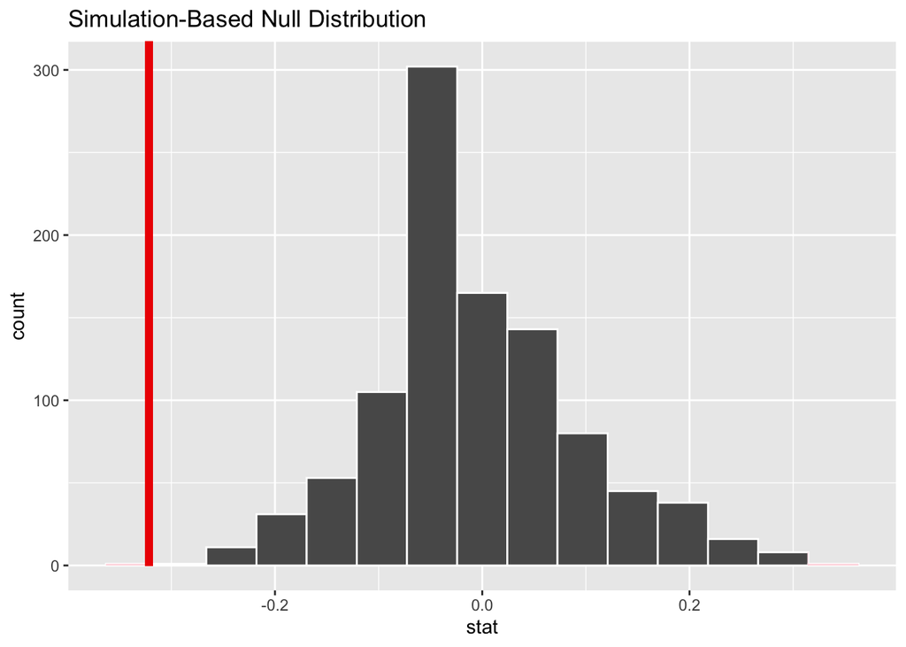

```r
ate_null_dist <- stateofficials |>
  specify(white ~ party) |>
  hypothesize(null = "independence") |>
  generate(reps = 1000, type = "permute") |>
  calculate(stat = "diff in means", order = c("Democrat", "Republican"))

visualize(ate_null_dist) + shade_p_value(obs_stat = ate, direction = "both")
```

```r
ate_p <- get_p_value(ate_null_dist, obs_stat = ate, direction = "both")
print(ate_p)
```

```
## # A tibble: 1 × 1
##   p_value
##     <dbl>
## 1   0.002
```

##### Regression Model:

```r
library(modelsummary)

regression_model <- stateofficials |>
  lm(formula = white ~ party)

var_labels <- c(
"(Intercept)" = "Intercept",
"partyRepublican" = "Republican Party")

modelsummary::modelsummary(regression_model,
                           statistic = c("s.e. = {std.error}",
                                         "p = {p.value}"),
                           coef_map = var_labels,
                           gof_map= c("nobs", "r.squared", "adj.r.squared"))
```

|  | (1) |
| --- | --- |
| Intercept | 0.522 |
|  | s.e. = 0.050 |
|  | p = <0.001 |
| Republican Party | 0.322 |
|  | s.e. = 0.097 |
|  | p = 0.001 |
| Num.Obs. | 122 |
| R2 | 0.084 |
| R2 Adj. | 0.076 |

I hypothesized that there would be a direct relationship between the percentage of white female elected officials in the House of Representatives and the political party. In this experiment, to statistically prove this hypothesis, the difference-in-means and regression model must suggest that we can reject the null hypothesis (that the independent variable does not effect the outcome, or in other words, that the percentage of white female elected officials is not influenced by party affiliation).

After our initial analysis of the first two figures, the third grouped bar plot illustrates POC versus white representatives per party and offers a side-by-side comparison. The findings from the first two figures are echoed by this third figure as the POC versus white bars in the Democratic party are fairly comparable whereas in the Republican party there are tremendous discrepancies (~47 vs 43 and ~27 vs 5 respectively). This once more suggests that there will be statistically strong correlation between the percentage of white female elected officials and party affiliation.

The difference-in-means here represents the distribution of differences between the means of the independent and outcome variables obtained from 1000 repeated samples. Each of these bars corresponds to a different sample, and the height of these bars indicates the probability of observing each scenario. In contrast, the red line represents the difference-in-means based on a sample in the actual data set. If the red line sits among the center of the distribution, then the data suggests that the outcome variable is not statistically significant and the observed differences in the data set are likely due to chance. However, here we see the red line is on the extreme left tail of the distribution. With this in mind, the correlation above clearly shows that the outcome variable is statistically significant and we can likely reject the null hypothesis. The regression model continues to prove my initial hypothesis. The intercept value of 0.522 tells us that 52.2% of all female elected Democratic representatives are white. The 0.322 value corresponding to “Republican Party” tells us that upon shifting from Democratic to Republican female elected representatives, we add 32.3 percentage points. In other words, this line of data lets us know that approximately 84.5% of all Republican female elected representatives are white in comparison to only 52.2% of Democratic representatives.

This conclusion is further proven upon looking at the p-value. If we accept the standard alpha of 0.5, our difference-in-means p-value of 0.002 is significantly less than our alpha, once more suggesting that we can safely reject the null hypothesis that there is no relationship between the percentage of white female elected officials and party affiliation. Furthermore, our regression model p-value of 0.001 is still under the alpha of 0.5 which lets us know that we can still safely reject the null hypothesis and the data demonstrates that there is a statistically significant relationship between the percentage of elected white female representatives and political party.

# Conclusion

Overall, it appears there is statistically significant evidence for the hypothesis that there is strong correlation between the percentage of white female elected officials in the House of Representatives and political affiliation. Not only was our p-value significantly less than the experimentally set alpha (0.002/ 0.001 vs 0.5) which numerically proves correlation, but qualitatively, the overall racial distribution in the Democratic party clearly shows a more equal distribution between POC and non-POC offcials than in the Republican. A potential limitation to this study is the fact that there are more female Democratic officials than Republican so it is inevitable that there would be greater observed racial distribution. This factor has the ability to affect both the response and explanatory variable. However, considering this study looked at the relationship of POC versus non POC elected officials per party before directly comparing the two, this data quantity difference should not have skewed the results too drastically. If there was more time and were more financial resources to conduct this study, I would personally analyze the overall POC vs non POC representation in all elected officials in the House of Representatives to avoid any data quantity discrepancies. Additionally, since this data set also lists the district and state of each female representative, it would be interesting to get more granular with my analysis and see if the political affiliation of the state/ district impacts the number of female/ POC elected representatives.